# Intro to Data Science - HW 5

##### Copyright Jeffrey Stanton, Jeffrey Saltz, and Jasmina Tacheva

```r
# Enter your name here: Mark Cappielo
```

### Attribution statement: (choose only one and delete the rest)

```r
#
# 2. I did this homework with help from the book and the professor and these Internet sources:
# I also recently bought a book called "Learning R" written by Richard Cotton published by O'Reilly Media Inc. 2013
```

**This module:** **Data visualization** is important because many people can make sense of data more easily when it is presented in graphic form. As a data scientist, you will have to present complex data to decision makers in a form that makes the data interpretable for them. From your experience with Excel and other tools, you know that there are a variety of **common data visualizations** (e.g., pie charts). How many of them can you name?

The most powerful tool for data visualization in R is called **ggplot**. Written by computer/data scientist **Hadley Wickham**, this **“graphics grammar”** tool builds visualizations in layers. This method provides immense flexibility, but takes a bit of practice to master.

## Step 1: Make a copy of the data

1. Read the **who** dataset from this URL: https://intro-datascience.s3.us-east-2.amazonaws.com/who.csv  
   into a new dataframe called **tb**.

Your new dataframe, tb, contains a so-called **multivariate time series**: a sequence of measurements on 23 Tuberculosis-related (TB) variables captured repeatedly over time (1980-2013). Familiarize yourself with the nature of the 23 variables by consulting the dataset’s codebook which can be found here: https://intro-datascience.s3.us-east-2.amazonaws.com/TB_data_dictionary_2021-02-06.csv.

```r
library(tidyverse)
tb <- read_csv(file = 'https://intro-datascience.s3.us-east-2.amazonaws.com/who.csv',show_col_types = FALSE)
```

2. How often were these measurements taken (in other words, at what frequency were the variables measured)? Put your answer in a comment.

```r
#--- Measurements appear to be taken annually
```

## Step 2: Clean-up the NAs and create a subset

1. Let’s clean up the iso2 attribute in **tb**

Hint: use *is.na()* – well use *! is.na()*

```r
#--- Cleaning up the iso2 attribute
tb <- tb[!is.na(tb$iso2),]
```

B. Create a subset of **tb** containing **only the records for Canada (“CA” in the iso2 variable)**. Save it in a new dataframe called **tbCan**. Make sure this new df has **29 observations and 23 variables**.

```r
tbCan <- tb[tb$iso2 == "CA",]
```

C. A simple method for dealing with small amounts of **missing data** in a numeric variable is to **substitute the mean of the variable in place of each missing datum**.  
This expression locates (and reports to the console) all the missing data elements in the variable measuring the **number of positive pulmonary smear tests for male children 0-4 years old** (there are 26 data points missing)

```r
tbCan$new_sp_m04[is.na(tbCan$new_sp_m04)]
```

```
##  [1] NA NA NA NA NA NA NA NA NA NA NA NA NA NA NA NA NA NA NA NA NA NA NA NA NA
## [26] NA
```

```r
#--- tbCan$new_sp_m04
#--- is.na(tbCan$new_sp_m04)
```

[output not shown]

4. Write a comment describing how that statement works.

```r
#--- Starting from the inner most grouping and working outward
#--- (tbCan$new_sp_m04) finds all of the values in data frame tbCan and column new_sp_m04
#---  it returns these values as a vector
#--- Using the is.na() function on (tbCan$new_sp_m04) returns only TRUE or FALSE for these values.
#---  "NA" will return a TRUE. A value other than NA will return a FALSE
#--- [is.na(tbCan$new_sp_m04)] is an index of this vector of all TRUEs, only for values which are equal to NA
#--- Based on the index created by the previous line, the NA values will be selected from
#--- the vector tbCan$new_sp_m04
```

5. Write 4 more statements to check if there is missing data for the number of positive pulmonary smear tests for: **male and female** children 0-14 years old (**new_sp_m014** and **new_sp_f014**), and **male and female citizens 65 years of age and older**, respectively. What does empty output suggest about the number of missing observations?

```r
#--- male children 0-14 years old
tbCan$new_sp_m014[is.na(tbCan$new_sp_m014)]
```

```
## numeric(0)
```

```r
#--- female children 0-14 years old
tbCan$new_sp_f014[is.na(tbCan$new_sp_f014)]
```

```
## numeric(0)
```

```r
#--- male citizens 65 years of age and older
tbCan$new_sp_m65[is.na(tbCan$new_sp_m65)]
```

```
## numeric(0)
```

```r
#--- female citizens 65 years of age and older
tbCan$new_sp_f65[is.na(tbCan$new_sp_f65)]
```

```
## numeric(0)
```

```r
#--- running each line of code returns numeric(0). No values were NA or missing for any of these observations
```

There is an R package called **imputeTS** specifically designed to repair missing values in time series data. We will use this instead of mean substitution.  
The **na_interpolation()** function in this package takes advantage of a unique characteristic of time series data: **neighboring points in time can be used to “guess” about a missing value in between**.

6. Install the **imputeTS** package (if needed) and use **na_interpolation( )** on the variable from part C. Don’t forget that you need to save the results back to the **tbCan** dataframe. Also update any attribute discussed in part E (if needed).

```r
#--- install.packages("imputeTS")
library(imputeTS)
tbCan$new_sp_m04 <- na_interpolation(tbCan$new_sp_m04)
tbCan
```

```
## # A tibble: 29 × 23
##    iso2   year new_sp new_sp_m04 new_sp_m514 new_sp_m014 new_sp_m1524
##    <chr> <dbl>  <dbl>      <dbl>       <dbl>       <dbl>        <dbl>
##  1 CA     1980    951          1          NA          12           54
##  2 CA     1981    803          1          NA           8           49
##  3 CA     1982    812          1          NA           6           52
##  4 CA     1983    771          1          NA           9           47
##  5 CA     1984    811          1          NA           3           44
##  6 CA     1985    791          1          NA          11           42
##  7 CA     1986    752          1          NA           9           58
##  8 CA     1987    668          1          NA           9           40
##  9 CA     1988    682          1          NA           4           43
## 10 CA     1989    652          1          NA          10           45
## # ℹ 19 more rows
## # ℹ 16 more variables: new_sp_m2534 <dbl>, new_sp_m3544 <dbl>,
## #   new_sp_m4554 <dbl>, new_sp_m5564 <dbl>, new_sp_m65 <dbl>, new_sp_mu <dbl>,
## #   new_sp_f04 <dbl>, new_sp_f514 <dbl>, new_sp_f014 <dbl>, new_sp_f1524 <dbl>,
## #   new_sp_f2534 <dbl>, new_sp_f3544 <dbl>, new_sp_f4554 <dbl>,
## #   new_sp_f5564 <dbl>, new_sp_f65 <dbl>, new_sp_fu <dbl>
```

7. Rerun the code from C and E above to check that all missing data have been fixed.

```r
tbCan$new_sp_m04[is.na(tbCan$new_sp_m04)]
```

```
## numeric(0)
```

```r
#--- male children 0-14 years old
tbCan$new_sp_m014[is.na(tbCan$new_sp_m014)]
```

```
## numeric(0)
```

```r
#--- female children 0-14 years old
tbCan$new_sp_f014[is.na(tbCan$new_sp_f014)]
```

```
## numeric(0)
```

```r
#--- male citizens 65 years of age and older
tbCan$new_sp_m65[is.na(tbCan$new_sp_m65)]
```

```
## numeric(0)
```

```r
#--- female citizens 65 years of age and older
tbCan$new_sp_f65[is.na(tbCan$new_sp_f65)]
```

```
## numeric(0)
```

## Step 3: Use ggplot to explore the distribution of each variable

**Don’t forget to install and library the ggplot2 package.** Then:  
H. Create a histogram for **new_sp_m014**. Be sure to add a title and briefly describe what the histogram means in a comment.

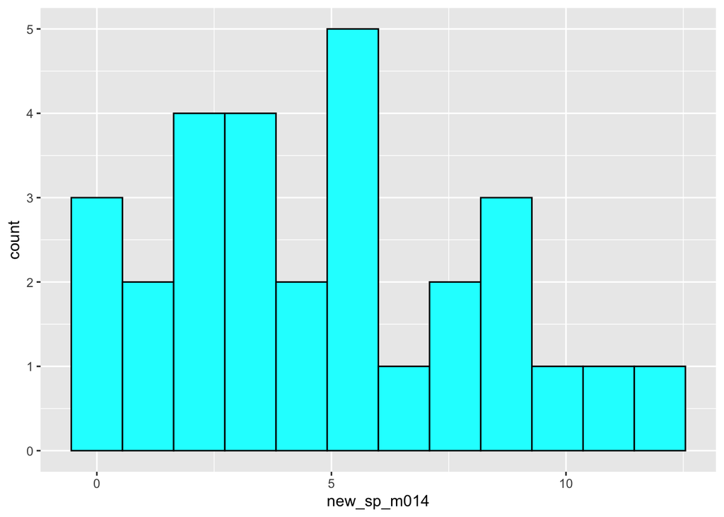

```r
library(tidyverse)
myPlot <- ggplot(tbCan)

#histogram new_sp_m04
#myPlot.new_sp_m04 <- myPlot + aes(x=new_sp_m04) + geom_histogram(bins = 12,fill = "yellow", col = "black")
#myPlot.new_sp_m04

#histogram new_sp_m014
myPlot.new_sp_m014 <- myPlot + aes(x=new_sp_m014) + geom_histogram(bins = 12,fill = "cyan", col = "black")
myPlot.new_sp_m014
```

1. Create histograms (using ggplot) of each of the other three variables from E with ggplot( ).  
   Which parameter do you need to adjust to make the other histograms look right?

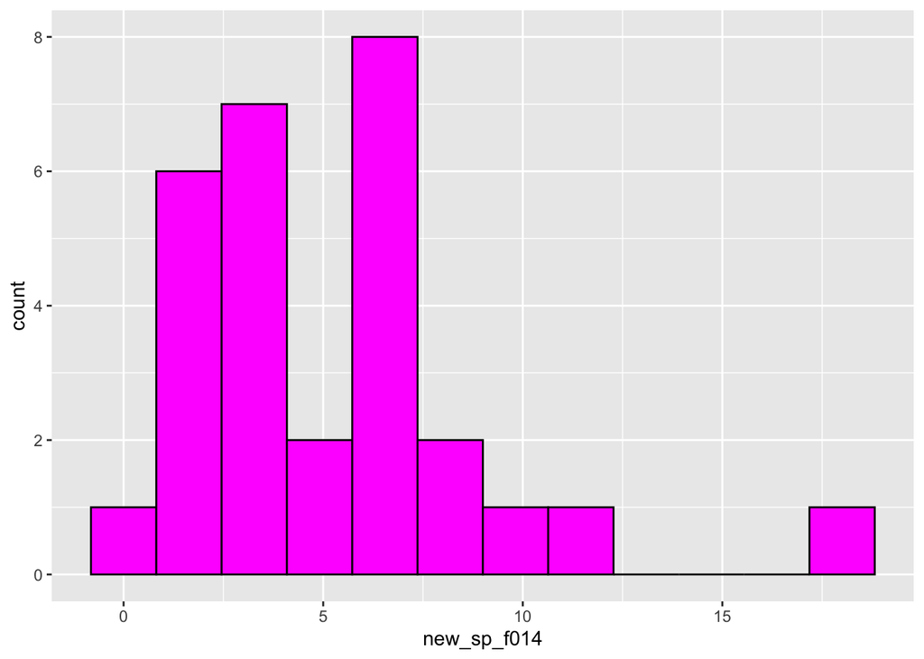

```r
#histogram new_sp_f014
myPlot.new_sp_f014 <- myPlot + aes(x=new_sp_f014) + geom_histogram(bins = 12,fill = "magenta", col = "black")
myPlot.new_sp_f014
```

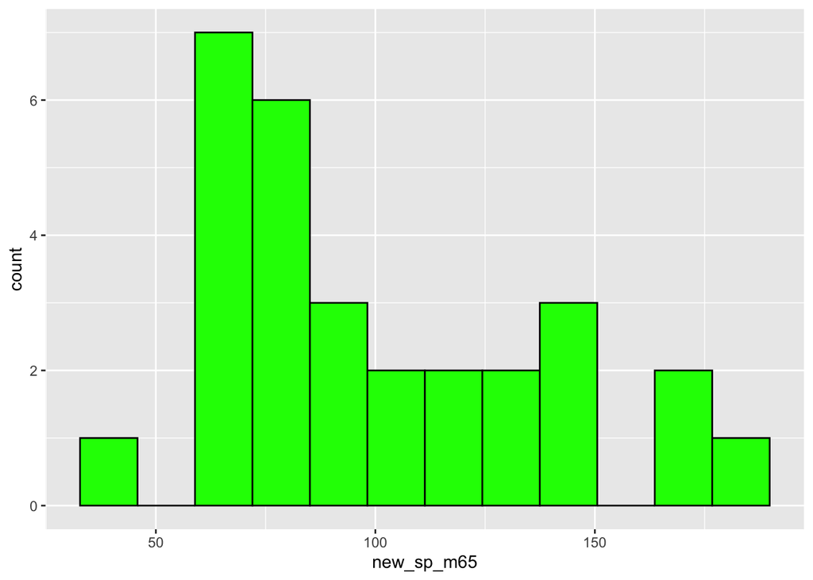

```r
#histogram new_sp_m65
myPlot.new_sp_m65 <- myPlot + aes(x=new_sp_m65) + geom_histogram(bins = 12,fill = "green1", col = "black")
myPlot.new_sp_m65
```

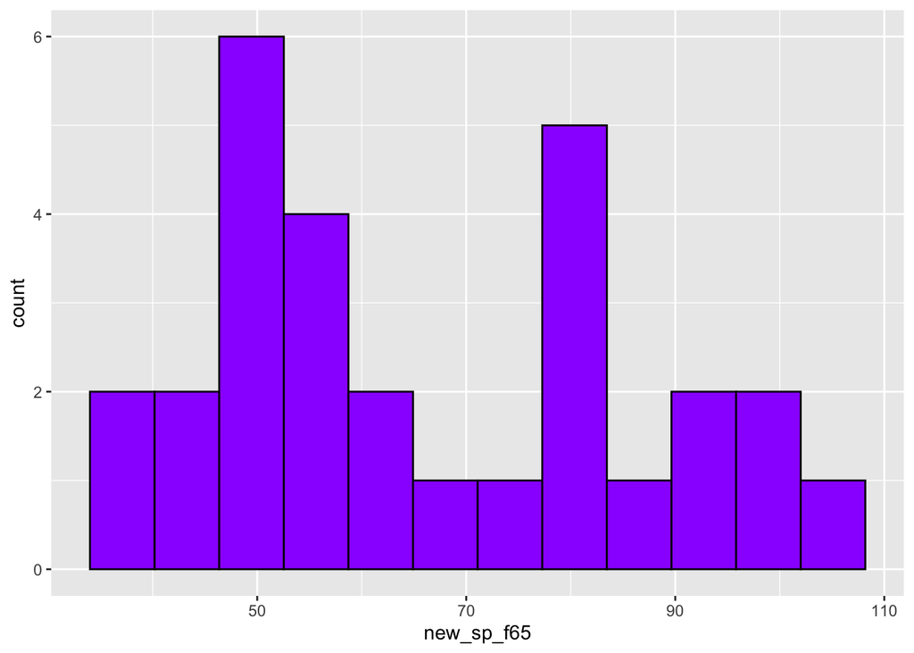

```r
#histogram new_sp_f65
myPlot.new_sp_f65 <- myPlot + aes(x=new_sp_f65) + geom_histogram(bins = 12,fill = "purple1", col = "black")
myPlot.new_sp_f65
```

## Step 4: Explore how the data changes over time

10. These data were collected in a period of several decades (1980-2013). You can thus observe changes over time with the help of a line chart. Create a **line chart**, with **year** on the X-axis and **new_sp_m014** on the Y-axis.

[figure not shown]

[output not shown]

[figure not shown]

```r
ggplot(tbCan, aes(x = year, y = new_sp_m014)) +
  geom_line(color = 'blue') +
  geom_point(color = 'blue') +
  labs(x = "Year", y = "Positive TB Tests", title = "Positive TB Tests new_sp_m014")
```

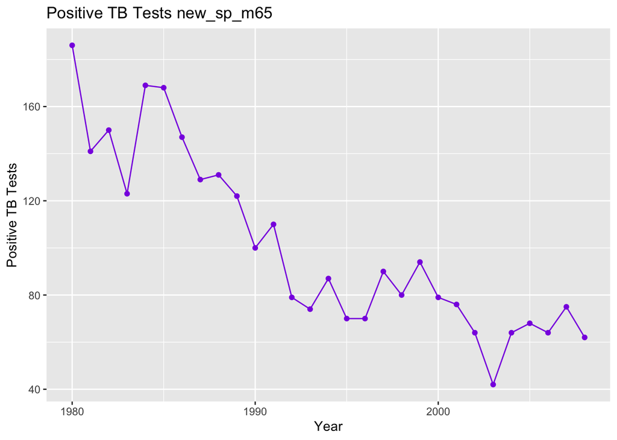

```r
ggplot(tbCan, aes(x = year, y = new_sp_m65)) +
  geom_line(color = 'blueviolet') +
  geom_point(color = 'blueviolet') +
  labs(x = "Year", y = "Positive TB Tests", title = "Positive TB Tests new_sp_m65")
```